# GEOmicroarrayDataAnalysis

mzagor

11 oktober 2016

```
################################################################################
# 1. Get the list of packages you have installed,
#    use priority to exclude base and recommended packages.
#    that may have been distributed with R.
# (pkgList <- installed.packages(priority='NA')[,'Package'])

# 2. Find out which packages are on CRAN and R-Forge.  Because
#    of R-Forge build capacity is currently limiting the number of
#    binaries available, it is queried for source packages only.
# (CRANpkgs <- available.packages(contriburl=contrib.url('http://cran.r-project.org'))[,'Package'])
# (forgePkgs <- available.packages(contriburl=contrib.url('http://r-forge.r-project.org', type='source'))[,'Package'])

# 3. Calculate the set of packages which are installed on your machine,
#    not on CRAN but also present on R-Force.
# (pkgsToUp <- intersect(setdiff(pkgList, CRANpkgs), forgePkgs))

# 4. Update the packages, using oldPkgs to restrict the list considered.
# update.packages(checkBuilt=TRUE, ask=FALSE, repos="http://r-forge.r-project.org", oldPkgs=pkgsToUp)
################################################################################

# Update all packages
# update.packages(ask = FALSE, dependencies = c('Suggests'))
```

```r
source("https://bioconductor.org/biocLite.R")
```

```
## Bioconductor version 3.4 (BiocInstaller 1.24.0), ?biocLite for help
```

```
## A new version of Bioconductor is available after installing the most
##   recent version of R; see http://bioconductor.org/install
```

```r
if (!require("GEOquery")) {
  biocLite("GEOquery")
}
```

```
## Setting options('download.file.method.GEOquery'='auto')
```

```
## Setting options('GEOquery.inmemory.gpl'=FALSE)
```

```r
library(GEOquery)

if (!require("Biobase")) {
  biocLite("Biobase")
}
library(Biobase)

if (!require("limma")) {
  biocLite("limma")
}
library(limma)
# source("http://bioconductor.org/biocLite.R")
# biocLite("genefilter")
# library(genefilter)
if (!require("plyr")) {
  install.packages(pkgs="plyr")
}
library(plyr)
# install.packages("XML", repos=c("http://rstudio.org/_packages", "http://cran.rstudio.com"))
# library("XML")
# install.packages("RCurl", repos=c("http://rstudio.org/_packages", "http://cran.rstudio.com"))
# library("RCurl")
# install.packages("rvest", repos=c("http://rstudio.org/_packages", "http://cran.rstudio.com"))
# library("rvest")
getPkgVigs()
```

```
##    package
## 1    limma
## 2 GEOquery
## 3  Biobase
## 4  Biobase
## 5  Biobase
## 6 parallel
## 7    utils
##                                                                       filename
## 1                       C:/Program Files/R/R-3.3.0/library/limma/doc/intro.pdf
## 2                C:/Program Files/R/R-3.3.0/library/GEOquery/doc/GEOquery.html
## 3        C:/Program Files/R/R-3.3.0/library/Biobase/doc/BiobaseDevelopment.pdf
## 4 C:/Program Files/R/R-3.3.0/library/Biobase/doc/ExpressionSetIntroduction.pdf
## 5                   C:/Program Files/R/R-3.3.0/library/Biobase/doc/esApply.pdf
## 6                 C:/Program Files/R/R-3.3.0/library/parallel/doc/parallel.pdf
## 7                      C:/Program Files/R/R-3.3.0/library/utils/doc/Sweave.pdf
##                                           title
## 1                   Limma One Page Introduction
## 2                                Using GEOquery
## 3                     Notes for eSet developers
## 4 An introduction to Biobase and ExpressionSets
## 5                          esApply Introduction
## 6                            Package 'parallel'
## 7                            Sweave User Manual
```

http://www.bioconductor.org/packages/release/bioc/manuals/Biobase/man/Biobase.pdf

http://www.bioconductor.org/packages/release/bioc/vignettes/Biobase/inst/doc/ExpressionSetIntroduction.pdf

http://www.bioconductor.org/packages/release/bioc/manuals/GEOquery/man/GEOquery.pdf

GEO Series (GSE), GEO platforms (GPL), and GEO samples (GSM)

The Gene Expression Omnibus (GEO) from NCBI serves as a public repository for a wide range of high-throughput experimental data. These data include single and dual channel microarray-based experiments measuring mRNA, genomic DNA, and protein abundance, as well as non-array techniques such as serial analysis of gene expression (SAGE), and mass spectrometry proteomic data. At the most basic level of organization of GEO, there are three entity types that may be supplied by users: Platforms, Samples, and Series. Additionally, there is a curated entity called a GEO dataset.

GDS-class: A class describing a GEO GDS entity

GEOData-class: virtual class for holding GEO samples, platforms, and datasets

GEODataTable-class: Contains the column descriptions and data for the datatable part of a GEO object

GPL-class: Contains a full GEO Platform entity

GSE-class: Contains a GEO Series entity

1. GPLList signature(object = “GSE”): returns a list, each item of the list being a GPL object
2. GSMList signature(object = “GSE”): returns a list, each item of the list being a GSM object
3. Meta signature(object = “GSE”): returns a list, the metadata associated with the GSE

GSM-class: A class containing a GEO Sample entity

1. getGEO

getGEO(GEO = NULL, filename = NULL, destdir = tempdir(), GSElimits=NULL, GSEMatrix=TRUE,AnnotGPL=FALSE,getGPL=TRUE)

This function is the main user-level function in the GEOquery package. It directs the download (if no filename is specified) and parsing of a GEO SOFT format file into an R data structure specifically designed to make access to each of the important parts of the GEO SOFT format easily accessible.

2. getGEOfile

getGEOfile(GEO, destdir = tempdir(), AnnotGPL = FALSE, amount = c(“full”, “brief”, “quick”, “data”))

This function simply downloads a SOFT format file associated with the GEO accession number given.

3. getGEOSuppFiles

getGEOSuppFiles(GEO, makeDirectory = TRUE, baseDir = getwd())

NCBI GEO allows supplemental files to be attached to GEO Series (GSE), GEO platforms (GPL), and GEO samples (GSM). This function “knows” how to get these files based on the GEO accession. No parsing of the downloaded files is attempted, since the file format is not generally knowable by the computer.

4. getGSEDataTables

getGSEDataTables(GSE)

In some cases, instead of individual sample records (GSM) containing information regarding sample phenotypes, the GEO Series contains that information in an attached data table. And example is given by GSE3494 where there are two data tables with important information contained within them. Using getGEO with the standard parameters downloads the GSEMatrix file which, unfortunately, does not contain the information in the data tables. This function simply downloads the “header” information from the GSE record and parses out the data tables into R data.frames.

5. parseGEO

parseGEO(fname, GSElimits, destdir=tempdir(), AnnotGPL=FALSE, getGPL=TRUE)

parseGPL(fname)

parseGDS(fname)

parseGSE(fname, GSElimits)

parseGSM(fname)

6. Functions to take a GDS data structure from getGEO and coerce it to limma MALists or ExpressionSets.

GDS2MA(GDS,do.log2=FALSE,GPL=NULL,AnnotGPL=TRUE,getGPL=TRUE)

GDS2eSet(GDS,do.log2=FALSE,GPL=NULL,AnnotGPL=TRUE,getGPL=TRUE)

7. gunzip

gunzip(filename, destname = gsub(“[.]gz$”, “”, filename), overwrite = FALSE, remove = TRUE, …

Gene Expression Omnibus: https://www.ncbi.nlm.nih.gov/geo/

GSE56094

https://www.ncbi.nlm.nih.gov/pmc/articles/PMC4682296/

[output not shown]

The aim of the Complete Arabidopsis Transcriptome MicroArray (CATMA) project was the design and production of high quality Gene-specific Sequence Tags (GSTs) covering most Arabidopsis genes. The GST repertoire is used by numerous groups for the production of DNA arrays for transcript profiling experiments.

CATMA microarrays constitute the foundation of the CAGE project aiming at the construction of a gene expression reference database for Arabidopsis. The CATMA GSTs are also the basic materials in the AGRIKOLA project focusing on the large-scale systematic RNAi silencing of Arabidopsis genes.

Get GEO data

GSE56094

```r
# http://bioconductor.org/packages/release/bioc/vignettes/GEOquery/inst/doc/GEOquery.html

# https://support.bioconductor.org/p/33487/
# you can run limma for differential expression analysis on your object 'gse' which is a list of ExpressionSets,
# which contains one single element because the dataset is not too large.
# This contains normalized log2 ratios after pre-processing done by the authors.

# assumes only one platform in the GSE
gse = getGEO('GSE56094')[[1]]
save (gse, file = 'GEO_GSE56094.RData')
# gse = get(load('GEO_GSE56094.RData'))
class(gse)
```

```
## [1] "ExpressionSet"
## attr(,"package")
## [1] "Biobase"
```

```r
classVersion(gse)
```

```
##             R       Biobase          eSet ExpressionSet
##       "3.3.1"      "2.34.0"       "1.3.0"       "1.0.0"
```

```r
description(gse)
```

```
## Experiment data
##   Experimenter name:
##   Laboratory:
##   Contact information:
##   Title:
##   URL:
##   PMIDs:
##   No abstract available.
```

```r
show(gse)
```

```
## ExpressionSet (storageMode: lockedEnvironment)
## assayData: 30336 features, 156 samples
##   element names: exprs
## protocolData: none
## phenoData
##   sampleNames: GSM1354976 GSM1354977 ... GSM1355131 (156 total)
##   varLabels: title geo_accession ... data_row_count (38 total)
##   varMetadata: labelDescription
## featureData
##   featureNames: CATMA1a00010 CATMA1a00020 ... CATMA5ctrl30 (30336
##     total)
##   fvarLabels: ID Chrom ... SPOT_ID (7 total)
##   fvarMetadata: Column Description labelDescription
## experimentData: use 'experimentData(object)'
## Annotation: GPL10840
```

```r
varMetadata(gse)
```

```
##                         labelDescription
## title                               <NA>
## geo_accession                       <NA>
## status                              <NA>
## submission_date                     <NA>
## last_update_date                    <NA>
## type                                <NA>
## channel_count                       <NA>
## source_name_ch1                     <NA>
## organism_ch1                        <NA>
## characteristics_ch1                 <NA>
## characteristics_ch1.1               <NA>
## characteristics_ch1.2               <NA>
## characteristics_ch1.3               <NA>
## growth_protocol_ch1                 <NA>
## molecule_ch1                        <NA>
## extract_protocol_ch1                <NA>
## label_ch1                           <NA>
## label_protocol_ch1                  <NA>
## taxid_ch1                           <NA>
## hyb_protocol                        <NA>
## scan_protocol                       <NA>
## scan_protocol.1                     <NA>
## description                         <NA>
## data_processing                     <NA>
## platform_id                         <NA>
## contact_name                        <NA>
## contact_email                       <NA>
## contact_department                  <NA>
## contact_institute                   <NA>
## contact_address                     <NA>
## contact_city                        <NA>
## contact_zip/postal_code             <NA>
## contact_country                     <NA>
## supplementary_file                  <NA>
## supplementary_file.1                <NA>
## supplementary_file.2                <NA>
## supplementary_file.3                <NA>
## data_row_count                      <NA>
```

```r
protocolData(gse)
```

```
## An object of class 'AnnotatedDataFrame': none
```

```r
# isnorm = getGEO('GSE56094', GSEMatrix=FALSE)
# head(Meta(isnorm))
# names(GSMList(isnorm))
# GSMList(isnorm)[[1]]
featureData(gse)
```

```
## An object of class 'AnnotatedDataFrame'
##   featureNames: CATMA1a00010 CATMA1a00020 ... CATMA5ctrl30 (30336
##     total)
##   varLabels: ID Chrom ... SPOT_ID (7 total)
##   varMetadata: Column Description labelDescription
```

```r
(info = varLabels(gse))
```

```
##  [1] "title"                   "geo_accession"
##  [3] "status"                  "submission_date"
##  [5] "last_update_date"        "type"
##  [7] "channel_count"           "source_name_ch1"
##  [9] "organism_ch1"            "characteristics_ch1"
## [11] "characteristics_ch1.1"   "characteristics_ch1.2"
## [13] "characteristics_ch1.3"   "growth_protocol_ch1"
## [15] "molecule_ch1"            "extract_protocol_ch1"
## [17] "label_ch1"               "label_protocol_ch1"
## [19] "taxid_ch1"               "hyb_protocol"
## [21] "scan_protocol"           "scan_protocol.1"
## [23] "description"             "data_processing"
## [25] "platform_id"             "contact_name"
## [27] "contact_email"           "contact_department"
## [29] "contact_institute"       "contact_address"
## [31] "contact_city"            "contact_zip/postal_code"
## [33] "contact_country"         "supplementary_file"
## [35] "supplementary_file.1"    "supplementary_file.2"
## [37] "supplementary_file.3"    "data_row_count"
```

```r
for (i in info) {
  if (!grepl('/', i)) {
    cat(i, '::\t')
    print(eval(parse(text = paste0('gse$',i,'[[1]]'))))
    cat('\n')
  }
}
```

```
## title :: [1] Mock 1 hours biorep A
## 156 Levels: Mock 1 hours biorep A ... P. syringae pv tomato DC3000 wildtype 9 hours biorep D
##
## geo_accession :: [1] GSM1354976
## 156 Levels: GSM1354976 GSM1354977 GSM1354978 GSM1354979 ... GSM1355131
##
## status ::    [1] Public on Jun 02 2015
## Levels: Public on Jun 02 2015
##
## submission_date ::   [1] Mar 21 2014
## Levels: Mar 21 2014
##
## last_update_date ::  [1] Jun 03 2015
## Levels: Jun 03 2015
##
## type ::  [1] RNA
## Levels: RNA
##
## channel_count :: [1] 1
## Levels: 1
##
## source_name_ch1 ::   [1] Mock 1 hours biorep A
## 156 Levels: Mock 1 hours biorep A ... P. syringae pv tomato DC3000 wildtype 9 hours biorep D
##
## organism_ch1 ::  [1] Arabidopsis thaliana
## Levels: Arabidopsis thaliana
##
## characteristics_ch1 ::   [1] strain: Col0
## Levels: strain: Col0
##
## characteristics_ch1.1 :: [1] treatment: Mock
## 3 Levels: treatment: Infected P. syringae pv tomato DC3000 hrpA- mutant ...
##
## characteristics_ch1.2 :: [1] hours_since_infection: 1
## 13 Levels: hours_since_infection: 1 ... hours_since_infection: 9
##
## characteristics_ch1.3 :: [1] tissue: leaf
## Levels: tissue: leaf
##
## growth_protocol_ch1 ::   [1] Arabidopsis plants Col-0 were grown under a 16:8 hr light:dark cycle (lights on 04:00 to 20:00) at 20Â°C, 60% humidity and light intensity of 100 ÎĽmol photons.m-2.s-1. Arabidopsis seed was stratified for three days in 0.1% agar at 4Â°C before sowing onto Arabidopsis …
```

[output cut: 55 more lines]

```
##
## supplementary_file ::    [1] ftp://ftp.ncbi.nlm.nih.gov/pub/geo/DATA/supplementary/samples/GSM1354nnn/GSM1354976/GSM1354976_LB_13781092_Cy5.txt.gz
## 156 Levels: ftp://ftp.ncbi.nlm.nih.gov/pub/geo/DATA/supplementary/samples/GSM1354nnn/GSM1354976/GSM1354976_LB_13781092_Cy5.txt.gz ...
##
## supplementary_file.1 ::  [1] ftp://ftp.ncbi.nlm.nih.gov/pub/geo/DATA/supplementary/samples/GSM1354nnn/GSM1354976/GSM1354976_LB_13781096_Cy3.txt.gz
## 156 Levels: ftp://ftp.ncbi.nlm.nih.gov/pub/geo/DATA/supplementary/samples/GSM1354nnn/GSM1354976/GSM1354976_LB_13781096_Cy3.txt.gz ...
##
## supplementary_file.2 ::  [1] ftp://ftp.ncbi.nlm.nih.gov/pub/geo/DATA/supplementary/samples/GSM1354nnn/GSM1354976/GSM1354976_LB_13781649_Cy5.txt.gz
## 156 Levels: ftp://ftp.ncbi.nlm.nih.gov/pub/geo/DATA/supplementary/samples/GSM1354nnn/GSM1354976/GSM1354976_LB_13781649_Cy5.txt.gz ...
##
## supplementary_file.3 ::  [1] ftp://ftp.ncbi.nlm.nih.gov/pub/geo/DATA/supplementary/samples/GSM1354nnn/GSM1354976/GSM1354976_LB_13876881_Cy3.txt.gz
## 156 Levels: ftp://ftp.ncbi.nlm.nih.gov/pub/geo/DATA/supplementary/samples/GSM1354nnn/GSM1354976/GSM1354976_LB_13876881_Cy3.txt.gz ...
##
## data_row_count ::    [1] 30336
## Levels: 30336
```

```r
fvarMetadata(gse)
```

```
##                    Column
## ID                     ID
## Chrom               Chrom
## TAIR9_best     TAIR9_best
## TAIR9_others TAIR9_others
## SEQUENCE         SEQUENCE
## ORF                   ORF
## SPOT_ID           SPOT_ID
##                                                                                       Description
## ID
## Chrom                    TAIR9 pseudochromosome containing best BLAST alignment to probe sequence
## TAIR9_best   TAIR9 gene model whose mRNA sequence contains best BLAST alignment to probe sequence
## TAIR9_others                            Other TAIR9 gene models with alignments to probe sequence
## SEQUENCE                                                                            Probe sequece
## ORF                     LINK_PRE:"http://www.ncbi.nlm.nih.gov/gene/?term=" LINK_SUF:"[gene name]"
## SPOT_ID
##              labelDescription
## ID                       <NA>
## Chrom                    <NA>
## TAIR9_best               <NA>
## TAIR9_others             <NA>
## SEQUENCE                 <NA>
## ORF                      <NA>
## SPOT_ID                  <NA>
```

```r
head(fData(gse))
```

```
##                        ID Chrom TAIR9_best TAIR9_others
## CATMA1a00010 CATMA1a00010     1  AT1G01010
## CATMA1a00020 CATMA1a00020     1  AT1G01020    AT1G05400
## CATMA1a00030 CATMA1a00030     1  AT1G01030
## CATMA1a00035 CATMA1a00035     1  AT1G01040
## CATMA1a00040 CATMA1a00040     1  AT1G01050
## CATMA1a00045 CATMA1a00045     1  AT1G01060
##                                                                                                                                                                                                                                                                                                          …
## CATMA1a00010                                                                                                                                     TCAACCAATCACGTCAACGAAATTCAGGATCTTACAACACTTACTCTGAGTATGATTCAG…
## CATMA1a00020                                                                                                                                                                                           GTGGTGGTACCCTCCTTGGAATGGTGGGCATATGTGGAACCCTCCTATGAATGTTGGAGA…
## CATMA1a00030                                                                                                                                                                                    CCAAACTTTACATAGATTGGAGGCATAGACCCGACATGAGCCTCGTTCAAGCACATCAGT…
## CATMA1a00035                                                                                                                                                                                   GGCTCATGCAAAGAGATTTACGTTTGGGGTAAGAGTTAATACGAGCGATAGAGGATGGAC…
## CATMA1a00040                                                                                                                                                                                                                                                         AGCTTCTCCTCAGAAGATTTCTGCAGCATCTATGTT…
## CATMA1a00045 TCCTAATTTCAAAAGCCAGGATTCTTGTGCTGCAGACCAAGAAGGAGTAGTAATGATCGG…
##                    ORF SPOT_ID
## CATMA1a00010 AT1G01010
## CATMA1a00020 AT1G01020
## CATMA1a00030 AT1G01030
## CATMA1a00035 AT1G01040
## CATMA1a00040 AT1G01050
## CATMA1a00045 AT1G01060
```

```r
fvarLabels(gse)
```

```
## [1] "ID"           "Chrom"        "TAIR9_best"   "TAIR9_others"
## [5] "SEQUENCE"     "ORF"          "SPOT_ID"
```

Translation table: CATMA to Ath gene

```r
catma = fData(gse)
cColNames = fvarLabels(gse)
ncol = length(cColNames)
dim(catma)
```

```
## [1] 30336     7
```

```r
catma[catma==""]<-NA
numNAs <- apply(catma, 1, function(x) sum(is.na(x)))
length(numNAs) == dim(catma)[1]
```

```
## [1] TRUE
```

```r
sum(is.na(catma$TAIR9_best))
```

```
## [1] 2728
```

```r
# keep ones that have assigned Ath gene
catma = catma[!is.na(catma$TAIR9_best), ]
dim(catma)
```

```
## [1] 27608     7
```

Get expression values

```r
# write.table(data.frame(fData(gse),exprs(gse)),sep="\t",row.names=FALSE,file='testGSE56094Table.txt')
myE = exprs(gse)
head(myE)[,1:6]
```

```
##              GSM1354976 GSM1354977 GSM1354978 GSM1354979 GSM1354980
## CATMA1a00010   9.429444  11.295529  10.720168  11.131236  10.630403
## CATMA1a00020   7.983924   7.732327   7.730905   7.942637   7.696408
## CATMA1a00030   8.298806   8.758403   8.341977   8.835087   8.293516
## CATMA1a00035  10.233715  10.668946   9.881458  10.483725  10.122867
## CATMA1a00040  11.137192  10.798991  10.760669  11.094889  11.641954
## CATMA1a00045   9.907937   9.546775   9.292673   8.630197   8.611419
##              GSM1354981
## CATMA1a00010  10.856614
## CATMA1a00020   7.968995
## CATMA1a00030   8.387448
## CATMA1a00035  10.275984
## CATMA1a00040  11.872051
## CATMA1a00045   8.989938
```

```r
dim(myE)
```

```
## [1] 30336   156
```

```r
nold = dim(myE)[2]
```

Plot values per experiment

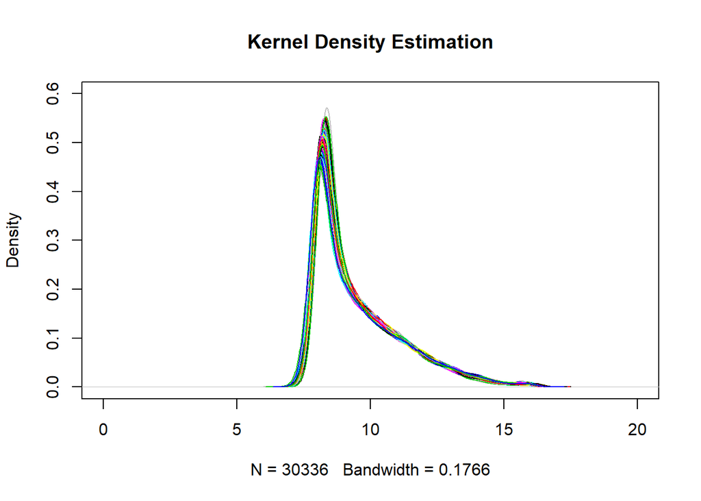

```r
# par(mfrow=c(2,1))
plot(density(myE[,1]), col=1, xlim=c(0,20), ylim=c(0,0.60), main = 'Kernel Density Estimation')
for (n in 2:nold) {lines(density(myE[,n]), col=n, xlim=c(0,20), ylim=c(0,0.60))}
```

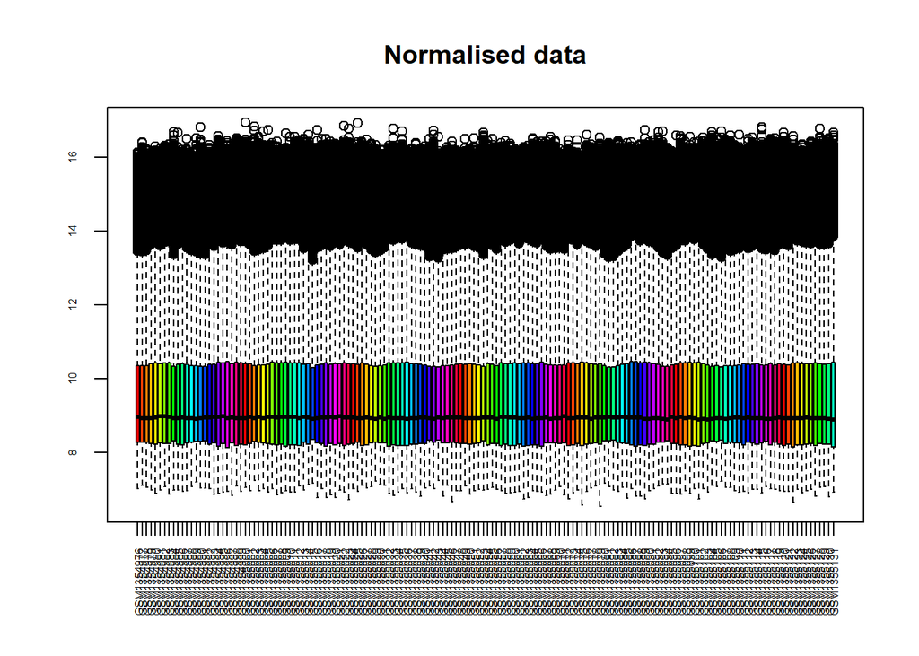

```r
boxplot(as.data.frame(myE[,1:nold]), col=rainbow(24), main= "Normalised data", las=3, cex.axis = 0.5)
```

```r
# par(mfrow=c(1,1))
```

Extract expression data for wanted experimets

| Order | Sample ID | Sample description | Order | Sample ID | Sample description | Order | Sample ID | Sample description |
| --- | --- | --- | --- | --- | --- | --- | --- | --- |
| 1 | GSM1354976 | Mock 1 hours biorep A | 53 | GSM1355028 | P. syringae pv tomato DC3000 hrpA- mutant 1 hours biorep A | 105 | GSM1355080 | P. syringae pv tomato DC3000 wildtype 1 hours biorep A |
| 2 | GSM1354977 | Mock 2 hours biorep A | 54 | GSM1355029 | P. syringae pv tomato DC3000 hrpA- mutant 2 hours biorep A | 106 | GSM1355081 | P. syringae pv tomato DC3000 wildtype 2 hours biorep A |
| 3 | GSM1354978 | Mock 3 hours biorep A | 55 | GSM1355030 | P. syringae pv tomato DC3000 hrpA- mutant 3 hours biorep A | 107 | GSM1355082 | P. syringae pv tomato DC3000 wildtype 3 hours biorep A |
| 4 | GSM1354979 | Mock 4 hours biorep A | 56 | GSM1355031 | P. syringae pv tomato DC3000 hrpA- mutant 4 hours biorep A | 108 | GSM1355083 | P. syringae pv tomato DC3000 wildtype 4 hours biorep A |
| 5 | GSM1354980 | Mock 5 hours biorep A | 57 | GSM1355032 | P. syringae pv tomato DC3000 hrpA- mutant 5 hours biorep A | 109 | GSM1355084 | P. syringae pv tomato DC3000 wildtype 5 hours biorep A |
| 6 | GSM1354981 | Mock 6 hours biorep A | 58 | GSM1355033 | P. syringae pv tomato DC3000 hrpA- mutant 6 hours biorep A | 110 | GSM1355085 | P. syringae pv tomato DC3000 wildtype 6 hours biorep A |
| 7 | GSM1354982 | Mock 7 hours biorep A | 59 | GSM1355034 | P. syringae pv tomato DC3000 hrpA- mutant 7 hours biorep A | 111 | GSM1355086 | P. syringae pv tomato DC3000 wildtype 7 hours biorep A |
| 8 | GSM1354983 | Mock 8 hours biorep A | 60 | GSM1355035 | P. syringae pv tomato DC3000 hrpA- mutant 8 hours biorep A | 112 | GSM1355087 | P. syringae pv tomato DC3000 wildtype 8 hours biorep A |
| 9 | GSM1354984 | Mock 9 hours biorep A | 61 | GSM1355036 | P. syringae pv tomato DC3000 hrpA- mutant 9 hours biorep A | 113 | GSM1355088 | P. syringae pv tomato DC3000 wildtype 9 hours biorep A |
| 10 | GSM1354985 | Mock 10 hours biorep A | 62 | GSM1355037 | P. syringae pv tomato DC3000 hrpA- mutant 10 hours biorep A | 114 | GSM1355089 | P. syringae pv tomato DC3000 wildtype 10 hours biorep A |
| 11 | GSM1354986 | Mock 11 hours biorep A | 63 | GSM1355038 | P. syringae pv tomato DC3000 hrpA- mutant 11 hours biorep A | 115 | GSM1355090 | P. syringae pv tomato DC3000 wildtype 11 hours biorep A |
| 12 | GSM1354987 | Mock 12 hours biorep A | 64 | GSM1355039 | P. syringae pv tomato DC3000 hrpA- mutant 12 hours biorep A | 116 | GSM1355091 | P. syringae pv tomato DC3000 wildtype 12 hours biorep A |
| 13 | GSM1354988 | Mock 13 hours biorep A | 65 | GSM1355040 | P. syringae pv tomato DC3000 hrpA- mutant 13 hours biorep A | 117 | GSM1355092 | P. syringae pv tomato DC3000 wildtype 13 hours biorep A |
| 14 | GSM1354989 | Mock 1 hours biorep B | 66 | GSM1355041 | P. syringae pv tomato DC3000 hrpA- mutant 1 hours biorep B | 118 | GSM1355093 | P. syringae pv tomato DC3000 wildtype 1 hours biorep B |
| 15 | GSM1354990 | Mock 2 hours biorep B | 67 | GSM1355042 | P. syringae pv tomato DC3000 hrpA- mutant 2 hours biorep B | 119 | GSM1355094 | P. syringae pv tomato DC3000 wildtype 2 hours biorep B |
| 16 | GSM1354991 | Mock 3 hours biorep B | 68 | GSM1355043 | P. syringae pv tomato DC3000 hrpA- mutant 3 hours biorep B | 120 | GSM1355095 | P. syringae pv tomato DC3000 wildtype 3 hours biorep B |
| 17 | GSM1354992 | Mock 4 hours biorep B | 69 | GSM1355044 | P. syringae pv tomato DC3000 hrpA- mutant 4 hours biorep B | 121 | GSM1355096 | P. syringae pv tomato DC3000 wildtype 4 hours biorep B |
| 18 | GSM1354993 | Mock 5 hours biorep B | 70 | GSM1355045 | P. syringae pv tomato DC3000 hrpA- mutant 5 hours biorep B | 122 | GSM1355097 | P. syringae pv tomato DC3000 wildtype 5 hours biorep B |
| 19 | GSM1354994 | Mock 6 hours biorep B | 71 | GSM1355046 | P. syringae pv tomato DC3000 hrpA- mutant 6 hours biorep B | 123 | GSM1355098 | P. syringae pv tomato DC3000 wildtype 6 hours biorep B |
| 20 | GSM1354995 | Mock 7 hours biorep B | 72 | GSM1355047 | P. syringae pv tomato DC3000 hrpA- mutant 7 hours biorep B | 124 | GSM1355099 | P. syringae pv tomato DC3000 wildtype 7 hours biorep B |
| 21 | GSM1354996 | Mock 8 hours biorep B | 73 | GSM1355048 | P. syringae pv tomato DC3000 hrpA- mutant 8 hours biorep B | 125 | GSM1355100 | P. syringae pv tomato DC3000 wildtype 8 hours biorep B |
| 22 | GSM1354997 | Mock 9 hours biorep B | 74 | GSM1355049 | P. syringae pv tomato DC3000 hrpA- mutant 9 hours biorep B | 126 | GSM1355101 | P. syringae pv tomato DC3000 wildtype 9 hours biorep B |
| 23 | GSM1354998 | Mock 10 hours biorep B | 75 | GSM1355050 | P. syringae pv tomato DC3000 hrpA- mutant 10 hours biorep B | 127 | GSM1355102 | P. syringae pv tomato DC3000 wildtype 10 hours biorep B |
| 24 | GSM1354999 | Mock 11 hours biorep B | 76 | GSM1355051 | P. syringae pv tomato DC3000 hrpA- mutant 11 hours biorep B | 128 | GSM1355103 | P. syringae pv tomato DC3000 wildtype 11 hours biorep B |
| 25 | GSM1355000 | Mock 12 hours biorep B | 77 | GSM1355052 | P. syringae pv tomato DC3000 hrpA- mutant 12 hours biorep B | 129 | GSM1355104 | P. syringae pv tomato DC3000 wildtype 12 hours biorep B |
| 26 | GSM1355001 | Mock 13 hours biorep B | 78 | GSM1355053 | P. syringae pv tomato DC3000 hrpA- mutant 13 hours biorep B | 130 | GSM1355105 | P. syringae pv tomato DC3000 wildtype 13 hours biorep B |
| 27 | GSM1355002 | Mock 1 hours biorep C | 79 | GSM1355054 | P. syringae pv tomato DC3000 hrpA- mutant 1 hours biorep C | 131 | GSM1355106 | P. syringae pv tomato DC3000 wildtype 1 hours biorep C |
| 28 | GSM1355003 | Mock 2 hours biorep C | 80 | GSM1355055 | P. syringae pv tomato DC3000 hrpA- mutant 2 hours biorep C | 132 | GSM1355107 | P. syringae pv tomato DC3000 wildtype 2 hours biorep C |
| 29 | GSM1355004 | Mock 3 hours biorep C | 81 | GSM1355056 | P. syringae pv tomato DC3000 hrpA- mutant 3 hours biorep C | 133 | GSM1355108 | P. syringae pv tomato DC3000 wildtype 3 hours biorep C |
| 30 | GSM1355005 | Mock 4 hours biorep C | 82 | GSM1355057 | P. syringae pv tomato DC3000 hrpA- mutant 4 hours biorep C | 134 | GSM1355109 | P. syringae pv tomato DC3000 wildtype 4 hours biorep C |
| 31 | GSM1355006 | Mock 5 hours biorep C | 83 | GSM1355058 | P. syringae pv tomato DC3000 hrpA- mutant 5 hours biorep C | 135 | GSM1355110 | P. syringae pv tomato DC3000 wildtype 5 hours biorep C |
| 32 | GSM1355007 | Mock 6 hours biorep C | 84 | GSM1355059 | P. syringae pv tomato DC3000 hrpA- mutant 6 hours biorep C | 136 | GSM1355111 | P. syringae pv tomato DC3000 wildtype 6 hours biorep C |
| 33 | GSM1355008 | Mock 7 hours biorep C | 85 | GSM1355060 | P. syringae pv tomato DC3000 hrpA- mutant 7 hours biorep C | 137 | GSM1355112 | P. syringae pv tomato DC3000 wildtype 7 hours biorep C |
| 34 | GSM1355009 | Mock 8 hours biorep C | 86 | GSM1355061 | P. syringae pv tomato DC3000 hrpA- mutant 8 hours biorep C | 138 | GSM1355113 | P. syringae pv tomato DC3000 wildtype 8 hours biorep C |
| 35 | GSM1355010 | Mock 9 hours biorep C | 87 | GSM1355062 | P. syringae pv tomato DC3000 hrpA- mutant 9 hours biorep C | 139 | GSM1355114 | P. syringae pv tomato DC3000 wildtype 9 hours biorep C |
| 36 | GSM1355011 | Mock 10 hours biorep C | 88 | GSM1355063 | P. syringae pv tomato DC3000 hrpA- mutant 10 hours biorep C | 140 | GSM1355115 | P. syringae pv tomato DC3000 wildtype 10 hours biorep C |
| 37 | GSM1355012 | Mock 11 hours biorep C | 89 | GSM1355064 | P. syringae pv tomato DC3000 hrpA- mutant 11 hours biorep C | 141 | GSM1355116 | P. syringae pv tomato DC3000 wildtype 11 hours biorep C |
| 38 | GSM1355013 | Mock 12 hours biorep C | 90 | GSM1355065 | P. syringae pv tomato DC3000 hrpA- mutant 12 hours biorep C | 142 | GSM1355117 | P. syringae pv tomato DC3000 wildtype 12 hours biorep C |
| 39 | GSM1355014 | Mock 13 hours biorep C | 91 | GSM1355066 | P. syringae pv tomato DC3000 hrpA- mutant 13 hours biorep C | 143 | GSM1355118 | P. syringae pv tomato DC3000 wildtype 13 hours biorep C |
| 40 | GSM1355015 | Mock 1 hours biorep D | 92 | GSM1355067 | P. syringae pv tomato DC3000 hrpA- mutant 1 hours biorep D | 144 | GSM1355119 | P. syringae pv tomato DC3000 wildtype 1 hours biorep D |
| 41 | GSM1355016 | Mock 2 hours biorep D | 93 | GSM1355068 | P. syringae pv tomato DC3000 hrpA- mutant 2 hours biorep D | 145 | GSM1355120 | P. syringae pv tomato DC3000 wildtype 2 hours biorep D |
| 42 | GSM1355017 | Mock 3 hours biorep D | 94 | GSM1355069 | P. syringae pv tomato DC3000 hrpA- mutant 3 hours biorep D | 146 | GSM1355121 | P. syringae pv tomato DC3000 wildtype 3 hours biorep D |
| 43 | GSM1355018 | Mock 4 hours biorep D | 95 | GSM1355070 | P. syringae pv tomato DC3000 hrpA- mutant 4 hours biorep D | 147 | GSM1355122 | P. syringae pv tomato DC3000 wildtype 4 hours biorep D |
| 44 | GSM1355019 | Mock 5 hours biorep D | 96 | GSM1355071 | P. syringae pv tomato DC3000 hrpA- mutant 5 hours biorep D | 148 | GSM1355123 | P. syringae pv tomato DC3000 wildtype 5 hours biorep D |
| 45 | GSM1355020 | Mock 6 hours biorep D | 97 | GSM1355072 | P. syringae pv tomato DC3000 hrpA- mutant 6 hours biorep D | 149 | GSM1355124 | P. syringae pv tomato DC3000 wildtype 6 hours biorep D |
| 46 | GSM1355021 | Mock 7 hours biorep D | 98 | GSM1355073 | P. syringae pv tomato DC3000 hrpA- mutant 7 hours biorep D | 150 | GSM1355125 | P. syringae pv tomato DC3000 wildtype 7 hours biorep D |
| 47 | GSM1355022 | Mock 8 hours biorep D | 99 | GSM1355074 | P. syringae pv tomato DC3000 hrpA- mutant 8 hours biorep D | 151 | GSM1355126 | P. syringae pv tomato DC3000 wildtype 8 hours biorep D |
| 48 | GSM1355023 | Mock 9 hours biorep D | 100 | GSM1355075 | P. syringae pv tomato DC3000 hrpA- mutant 9 hours biorep D | 152 | GSM1355127 | P. syringae pv tomato DC3000 wildtype 9 hours biorep D |
| 49 | GSM1355024 | Mock 10 hours biorep D | 101 | GSM1355076 | P. syringae pv tomato DC3000 hrpA- mutant 10 hours biorep D | 153 | GSM1355128 | P. syringae pv tomato DC3000 wildtype 10 hours biorep D |
| 50 | GSM1355025 | Mock 11 hours biorep D | 102 | GSM1355077 | P. syringae pv tomato DC3000 hrpA- mutant 11 hours biorep D | 154 | GSM1355129 | P. syringae pv tomato DC3000 wildtype 11 hours biorep D |
| 51 | GSM1355026 | Mock 12 hours biorep D | 103 | GSM1355078 | P. syringae pv tomato DC3000 hrpA- mutant 12 hours biorep D | 155 | GSM1355130 | P. syringae pv tomato DC3000 wildtype 12 hours biorep D |
| 52 | GSM1355027 | Mock 13 hours biorep D | 104 | GSM1355079 | P. syringae pv tomato DC3000 hrpA- mutant 13 hours biorep D | 156 | GSM1355131 | P. syringae pv tomato DC3000 wildtype 13 hours biorep D |

```r
# gse$title

# select only mock and DC3000 wt
myE = myE[,c(1:(13*4),((13*4*2+1):(13*4*3)))]
dim(myE)
```

```
## [1] 30336   104
```

```r
nold = dim(myE)[2]

# find match per CATMA
length(rownames(catma)) == length(unique(rownames(catma)))
```

```
## [1] TRUE
```

```r
ind = match(rownames(myE),rownames(catma))
myE = cbind(myE,catma[ind,])
dim(myE)
```

```
## [1] 30336   111
```

```r
# backup copy of expression file merged with pheno data
myEextended = myE

# find duplicated probes (one probe per gene)
# gives you a data frame with a list of ids and the number of times they occurred
n_occur <- data.frame(table(myE[,(nold+3)]))
# tells you which ids occurred more than once
duplicated = n_occur[n_occur$Freq > 1,]
# dim(duplicated)
sum(duplicated[,2])
```

```
## [1] 7000
```

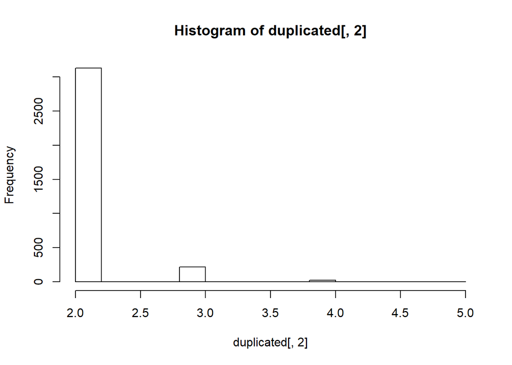

```r
hist(duplicated[,2])
```

```r
# returns the records with more than one occurrence
duplicatedID = myE[myE[,(nold+3)] %in% n_occur$Var1[n_occur$Freq > 1],]
dim(duplicatedID)
```

```
## [1] 7000  111
```

```r
length(unique(duplicatedID[,(nold+3)])) == dim(duplicated)[1]
```

```
## [1] TRUE
```

```r
myE = myE[,c(1:nold, nold+1, nold+3)]
# remove probes that are not annotated with Ath gene
myE = myE[!is.na(myE[,dim(myE)[2]]),]
any(is.na(myE[,dim(myE)[2]]))
```

```
## [1] FALSE
```

```r
dim(myE)
```

```
## [1] 27608   106
```

```r
# average probe expression for ones that are matching the same gene
X = aggregate(myE[,1:nold], by=list(myE$TAIR9_best), FUN=mean)
dim(X)[1] == length(unique(myE$TAIR9_best))
```

```
## [1] TRUE
```

```r
rownames(X) = X$Group.1
newCatma = rownames(X)
length(newCatma) == length(unique(newCatma))
```

```
## [1] TRUE
```

```r
any(colnames(X)[2:dim(X)[2]] != colnames(myE)[1:nold])
```

```
## [1] FALSE
```

```r
myE = X[,2:dim(X)[2]]
```

Phenodata

```r
dim((pData(phenoData(gse))))
```

```
## [1] 156  38
```

```r
colnames((pData(phenoData(gse))))
```

```
##  [1] "title"                   "geo_accession"
##  [3] "status"                  "submission_date"
##  [5] "last_update_date"        "type"
##  [7] "channel_count"           "source_name_ch1"
##  [9] "organism_ch1"            "characteristics_ch1"
## [11] "characteristics_ch1.1"   "characteristics_ch1.2"
## [13] "characteristics_ch1.3"   "growth_protocol_ch1"
## [15] "molecule_ch1"            "extract_protocol_ch1"
## [17] "label_ch1"               "label_protocol_ch1"
## [19] "taxid_ch1"               "hyb_protocol"
## [21] "scan_protocol"           "scan_protocol.1"
## [23] "description"             "data_processing"
## [25] "platform_id"             "contact_name"
## [27] "contact_email"           "contact_department"
## [29] "contact_institute"       "contact_address"
## [31] "contact_city"            "contact_zip/postal_code"
## [33] "contact_country"         "supplementary_file"
## [35] "supplementary_file.1"    "supplementary_file.2"
## [37] "supplementary_file.3"    "data_row_count"
```

```r
show(pData(phenoData(gse))[1:5,c(1,6,8)])
```

```
##                            title type       source_name_ch1
## GSM1354976 Mock 1 hours biorep A  RNA Mock 1 hours biorep A
## GSM1354977 Mock 2 hours biorep A  RNA Mock 2 hours biorep A
## GSM1354978 Mock 3 hours biorep A  RNA Mock 3 hours biorep A
## GSM1354979 Mock 4 hours biorep A  RNA Mock 4 hours biorep A
## GSM1354980 Mock 5 hours biorep A  RNA Mock 5 hours biorep A
```

```r
myP = (pData(phenoData(gse)))[,c(1,6,8)]
dim(myP)
```

```
## [1] 156   3
```

```r
head(myP)
```

```
##                            title type       source_name_ch1
## GSM1354976 Mock 1 hours biorep A  RNA Mock 1 hours biorep A
## GSM1354977 Mock 2 hours biorep A  RNA Mock 2 hours biorep A
## GSM1354978 Mock 3 hours biorep A  RNA Mock 3 hours biorep A
## GSM1354979 Mock 4 hours biorep A  RNA Mock 4 hours biorep A
## GSM1354980 Mock 5 hours biorep A  RNA Mock 5 hours biorep A
## GSM1354981 Mock 6 hours biorep A  RNA Mock 6 hours biorep A
```

```r
myP = myP[c(1:(13*4),((13*4*2+1):(13*4*3))),]
str(myP$source_name_ch1)
```

```
##  Factor w/ 156 levels "Mock 1 hours biorep A",..: 1 21 25 29 33 37 41 45 49 5 ...
##  - attr(*, "names")= chr [1:104] "V2" "V3" "V4" "V5" ...
```

```r
all(rownames(myP)==colnames(myE[,1:nold]))
```

```
## [1] TRUE
```

```r
# phenoData <- new("AnnotatedDataFrame",data=myP)
summary(myP)
```

```
##                     title     type                   source_name_ch1
##  Mock 1 hours biorep A : 1   RNA:104   Mock 1 hours biorep A : 1
##  Mock 1 hours biorep B : 1             Mock 1 hours biorep B : 1
##  Mock 1 hours biorep C : 1             Mock 1 hours biorep C : 1
##  Mock 1 hours biorep D : 1             Mock 1 hours biorep D : 1
##  Mock 10 hours biorep A: 1             Mock 10 hours biorep A: 1
##  Mock 10 hours biorep B: 1             Mock 10 hours biorep B: 1
##  (Other)               :98             (Other)               :98
```

```r
names(myP)
```

```
## [1] "title"           "type"            "source_name_ch1"
```

```r
sapply(myP, class)
```

```
##           title            type source_name_ch1
##        "factor"        "factor"        "factor"
```

Design (or model) matrix

```r
(lev <- unique(ldply(strsplit(gsub(" ", "_", as.character(myP$source_name_ch1),
                                  fixed = TRUE),
                             split = "_hours_biorep"))[[1]]))
```

```
##  [1] "Mock_1"
##  [2] "Mock_2"
##  [3] "Mock_3"
##  [4] "Mock_4"
##  [5] "Mock_5"
##  [6] "Mock_6"
##  [7] "Mock_7"
##  [8] "Mock_8"
##  [9] "Mock_9"
## [10] "Mock_10"
## [11] "Mock_11"
## [12] "Mock_12"
## [13] "Mock_13"
## [14] "P._syringae_pv_tomato_DC3000_wildtype_1"
## [15] "P._syringae_pv_tomato_DC3000_wildtype_2"
## [16] "P._syringae_pv_tomato_DC3000_wildtype_3"
## [17] "P._syringae_pv_tomato_DC3000_wildtype_4"
## [18] "P._syringae_pv_tomato_DC3000_wildtype_5"
## [19] "P._syringae_pv_tomato_DC3000_wildtype_6"
## [20] "P._syringae_pv_tomato_DC3000_wildtype_7"
## [21] "P._syringae_pv_tomato_DC3000_wildtype_8"
## [22] "P._syringae_pv_tomato_DC3000_wildtype_9"
## [23] "P._syringae_pv_tomato_DC3000_wildtype_10"
## [24] "P._syringae_pv_tomato_DC3000_wildtype_11"
## [25] "P._syringae_pv_tomato_DC3000_wildtype_12"
## [26] "P._syringae_pv_tomato_DC3000_wildtype_13"
```

```r
myP$source_name_ch1 = (ldply(strsplit(gsub(" ", "_", as.character(myP$source_name_ch1),
                                           fixed = TRUE),
                                      split = "_hours_biorep"))[[1]])
(f <- factor(myP$source_name_ch1, levels=lev))
```

```
##   [1] Mock_1
##   [2] Mock_2
##   [3] Mock_3
##   [4] Mock_4
##   [5] Mock_5
##   [6] Mock_6
##   [7] Mock_7
##   [8] Mock_8
##   [9] Mock_9
##  [10] Mock_10
##  [11] Mock_11
##  [12] Mock_12
##  [13] Mock_13
##  [14] Mock_1
##  [15] Mock_2
```

[output cut: 90 more lines]

```r
design <- model.matrix(~0+f)
dim(design)
```

```
## [1] 104  26
```

```r
which(design!=0,arr.ind = T)
```

```
##     row col
## 1     1   1
## 14   14   1
## 27   27   1
## 40   40   1
## 2     2   2
## 15   15   2
## 28   28   2
## 41   41   2
## 3     3   3
## 16   16   3
## 29   29   3
## 42   42   3
## 4     4   4
## 17   17   4
```

[output cut: 90 more lines]

```r
colnames(design) <- lev
rownames(design) = rownames(myP)
str(design)
```

```
##  num [1:104, 1:26] 1 0 0 0 0 0 0 0 0 0 ...
##  - attr(*, "dimnames")=List of 2
##   ..$ : chr [1:104] "GSM1354976" "GSM1354977" "GSM1354978" "GSM1354979" ...
##   ..$ : chr [1:26] "Mock_1" "Mock_2" "Mock_3" "Mock_4" ...
##  - attr(*, "assign")= int [1:26] 1 1 1 1 1 1 1 1 1 1 ...
##  - attr(*, "contrasts")=List of 1
##   ..$ f: chr "contr.treatment"
```

Fit linear model for each gene given a series of arrays

```r
fit <- lmFit(myE, design, weights=NULL)
summary(fit)
```

```
##                  Length Class  Mode
## coefficients     623324 -none- numeric
## rank                  1 -none- numeric
## assign               26 -none- numeric
## qr                    5 qr     list
## df.residual       23974 -none- numeric
## sigma             23974 -none- numeric
## cov.coefficients    676 -none- numeric
## stdev.unscaled   623324 -none- numeric
## pivot                26 -none- numeric
## Amean             23974 -none- numeric
## method                1 -none- character
## design             2704 -none- numeric
```

```r
colnames(fit$design)
```

```
##  [1] "Mock_1"
##  [2] "Mock_2"
##  [3] "Mock_3"
##  [4] "Mock_4"
##  [5] "Mock_5"
##  [6] "Mock_6"
##  [7] "Mock_7"
##  [8] "Mock_8"
##  [9] "Mock_9"
## [10] "Mock_10"
## [11] "Mock_11"
## [12] "Mock_12"
## [13] "Mock_13"
## [14] "P._syringae_pv_tomato_DC3000_wildtype_1"
## [15] "P._syringae_pv_tomato_DC3000_wildtype_2"
## [16] "P._syringae_pv_tomato_DC3000_wildtype_3"
## [17] "P._syringae_pv_tomato_DC3000_wildtype_4"
## [18] "P._syringae_pv_tomato_DC3000_wildtype_5"
## [19] "P._syringae_pv_tomato_DC3000_wildtype_6"
## [20] "P._syringae_pv_tomato_DC3000_wildtype_7"
## [21] "P._syringae_pv_tomato_DC3000_wildtype_8"
## [22] "P._syringae_pv_tomato_DC3000_wildtype_9"
## [23] "P._syringae_pv_tomato_DC3000_wildtype_10"
## [24] "P._syringae_pv_tomato_DC3000_wildtype_11"
## [25] "P._syringae_pv_tomato_DC3000_wildtype_12"
## [26] "P._syringae_pv_tomato_DC3000_wildtype_13"
```

```r
#colnames(fit65046.comp$contrasts)
#which(fit65046.comp$contrasts!=0,arr.ind = T)
```

Plot few pairs

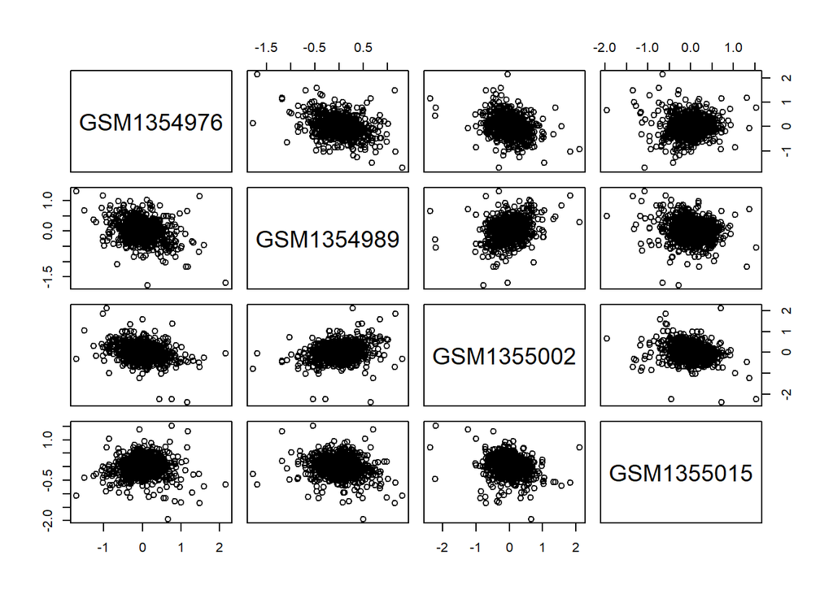

```r
pairs(myE[1:1000,c(1,14,27,40)]-myE[1:1000,c(1,14,27,40)+52])
```

Construct the contrast matrix corresponding to specified contrasts of a set of parameters.

```r
#     print(eval(parse(text = paste0('gse$',i,'[[1]]'))))
# http://www.bioconductor.org/packages/release/bioc/vignettes/limma/inst/doc/usersguide.pdf
contrast.matrix = makeContrasts(
  eval(parse(text = colnames(fit$design)[length(colnames(fit$design))/2 + 1])) -
    eval(parse(text = colnames(fit$design)[1])),
  eval(parse(text = colnames(fit$design)[length(colnames(fit$design))/2 + 2])) -
    eval(parse(text = colnames(fit$design)[2])),
  eval(parse(text = colnames(fit$design)[length(colnames(fit$design))/2 + 3])) -
    eval(parse(text = colnames(fit$design)[3])),
  eval(parse(text = colnames(fit$design)[length(colnames(fit$design))/2 + 4])) -
    eval(parse(text = colnames(fit$design)[4])),
  eval(parse(text = colnames(fit$design)[length(colnames(fit$design))/2 + 5])) -
    eval(parse(text = colnames(fit$design)[5])),
  eval(parse(text = colnames(fit$design)[length(colnames(fit$design))/2 + 6])) -
    eval(parse(text = colnames(fit$design)[6])),
  eval(parse(text = colnames(fit$design)[length(colnames(fit$design))/2 + 7])) -
    eval(parse(text = colnames(fit$design)[7])),
  eval(parse(text = colnames(fit$design)[length(colnames(fit$design))/2 + 8])) -
    eval(parse(text = colnames(fit$design)[8])),
  eval(parse(text = colnames(fit$design)[length(colnames(fit$design))/2 + 9])) -
    eval(parse(text = colnames(fit$design)[9])),
  eval(parse(text = colnames(fit$design)[length(colnames(fit$design))/2 + 10])) -
    eval(parse(text = colnames(fit$design)[10])),
  eval(parse(text = colnames(fit$design)[length(colnames(fit$design))/2 + 11])) -
    eval(parse(text = colnames(fit$design)[11])),
  eval(parse(text = colnames(fit$design)[length(colnames(fit$design))/2 + 12])) -
    eval(parse(text = colnames(fit$design)[12])),
  eval(parse(text = colnames(fit$design)[length(colnames(fit$design))/2 + 13])) -
    eval(parse(text = colnames(fit$design)[13])),
  levels=design)

# same as
# contrast.matrix.b = makeContrasts(P._syringae_pv_tomato_DC3000_wildtype_1 - Mock_1,
#                                 P._syringae_pv_tomato_DC3000_wildtype_2 - Mock_2,
#                                 P._syringae_pv_tomato_DC3000_wildtype_3 - Mock_3,
#                                 P._syringae_pv_tomato_DC3000_wildtype_4 - Mock_4,
#                                 P._syringae_pv_tomato_DC3000_wildtype_5 - Mock_5,
#                                 P._syringae_pv_tomato_DC3000_wildtype_6 - Mock_6,
#                                 P._syringae_pv_tomato_DC3000_wildtype_7 - Mock_7,
#                                 P._syringae_pv_tomato_DC3000_wildtype_8 - Mock_8,
#                                 P._syringae_pv_tomato_DC3000_wildtype_9 - Mock_9,
#                                 P._syringae_pv_tomato_DC3000_wildtype_10 - Mock_10,
#                                 P._syringae_pv_tomato_DC3000_wildtype_11 - Mock_11,
#                                 P._syringae_pv_tomato_DC3000_wildtype_12 - Mock_12,
#                                 P._syringae_pv_tomato_DC3000_wildtype_13 - Mock_13,
#                                 levels=design)
# any(contrast.matrix.b != contrast.matrix)
```

Compute Contrasts from Linear Model Fit

```r
fit.comp <- contrasts.fit(fit, contrast.matrix)
```

Empirical Bayes Statistics for Differential Expression

```r
fit.comp <- eBayes(fit.comp)
```

Examine unadjusted p-values

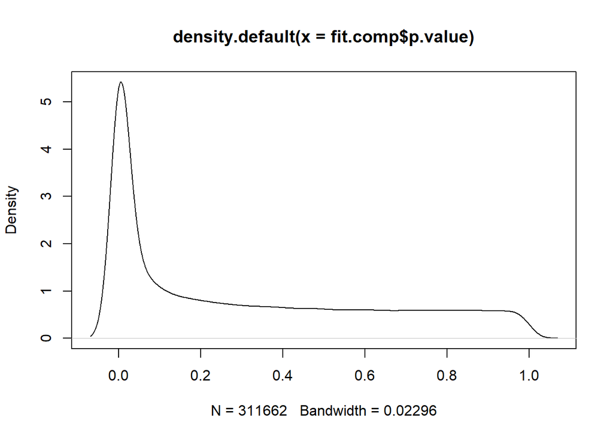

```r
plot(density(fit.comp$p.value))
```

Plot Venn diagrams per tp

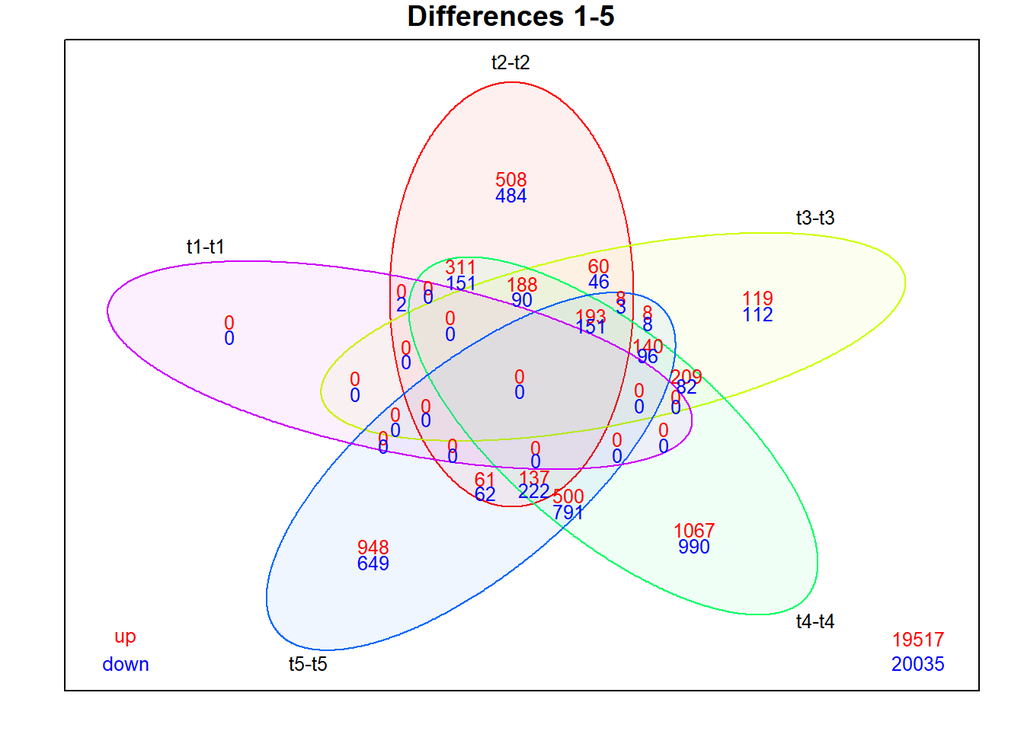

```r
# par(mfrow=c(2,2))
c_1_5 <- decideTests(fit.comp[, 1:5], adjust='BH', p.value=0.05)
vennDiagram(c_1_5, include=c("up", "down"), counts.col=c("red", "blue"),
            cex=c(0.8, 0.8, 0.8), circle.col=rainbow(5), show.include = TRUE,
            main = "Differences 1-5",
            names = c ("t1-t1", "t2-t2", "t3-t3", "t4-t4", "t5-t5"))
```

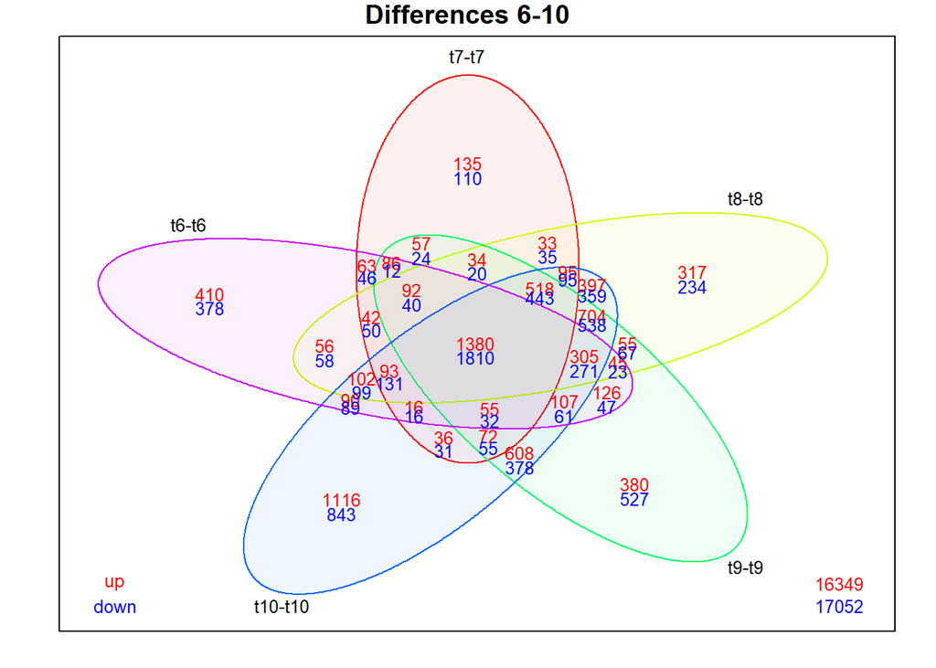

```r
c_6_10 <- decideTests(fit.comp[, 6:10], adjust='BH', p.value=0.05)
vennDiagram(c_6_10, include=c("up", "down"), counts.col=c("red", "blue"),
            cex=c(0.8, 0.8, 0.8), circle.col=rainbow(5), show.include = TRUE,
            main = "Differences 6-10",
            names = c ("t6-t6", "t7-t7", "t8-t8", "t9-t9", "t10-t10"))
```

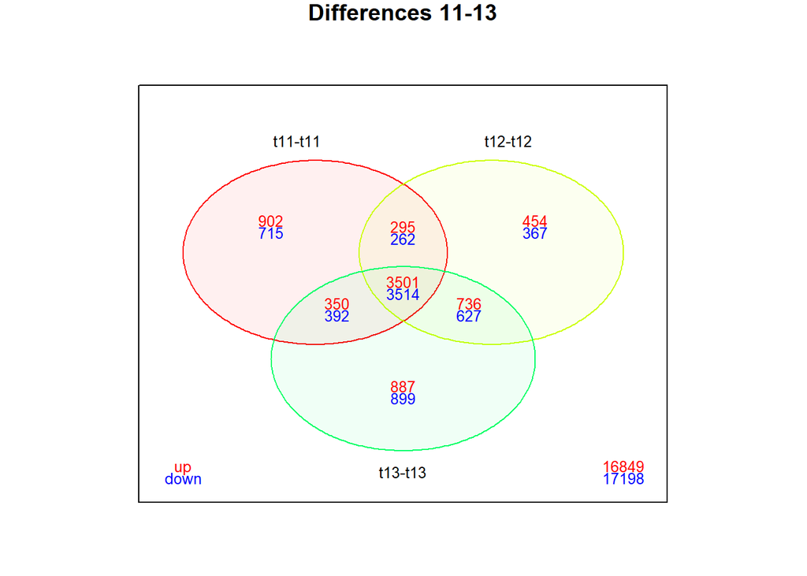

```r
c_11_13 <- decideTests(fit.comp[, 11:13], adjust='BH', p.value=0.05)
vennDiagram(c_11_13, include=c("up", "down"), counts.col=c("red", "blue"),
            cex=c(0.8, 0.8, 0.8), circle.col=rainbow(5), show.include = TRUE,
            main = "Differences 11-13",
            names = c ("t11-t11", "t12-t12", "t13-t13"))
```

```r
# par(mfrow=c(1,1))
```

Up/down-regulated genes in infected leaves

```r
temp = decideTests(fit.comp, adjust='fdr', p.value=0.05)
colnames(temp) = paste0('tp_',seq(1,13,1))
summary(temp)
```

```
##     tp_1  tp_2  tp_3  tp_4  tp_5  tp_6  tp_7  tp_8  tp_9 tp_10 tp_11 tp_12
## -1     2  1211   588  2573  1982  3163  2950  4273  4348  5251  4883  4770
## 0  23972 21297 22461 18656 19997 17743 18217 15433 15002 13029 14043 14218
## 1      0  1466   925  2745  1995  3068  2807  4268  4624  5694  5048  4986
##    tp_13
## -1  5432
## 0  13068
## 1   5474
```

Create output directory

```r
mainDir <- getwd()
subDir <- "outputDirectory_GSE56094"
if (file.exists(subDir)){
  setwd(file.path(mainDir, subDir))
} else {
  dir.create(file.path(mainDir, subDir))
  setwd(file.path(mainDir, subDir))

}
```

Write results

```r
tmp = getwd()
i = 1
comparisons <- topTable(fit.comp, coef=i, adjust='fdr', sort='p', n=Inf)
colnames(comparisons) = paste0(colnames(comparisons), '_tp_00', i)
head(comparisons)
```

```
##           logFC_tp_001 AveExpr_tp_001  t_tp_001 P.Value_tp_001
## AT5G62280   -1.1174457       9.307739 -6.396803   9.079465e-09
## AT4G32280   -0.8364199       8.454607 -5.069194   2.412759e-06
## AT5G66580   -0.7290080       9.549609 -4.759518   8.182172e-06
## AT4G22470    1.8837634      14.546944  4.388996   3.350426e-05
## AT5G18060   -0.6052422       8.600483 -4.292388   4.790469e-05
## AT4G34250   -0.6732834       8.489078 -4.245183   5.695893e-05
##           adj.P.Val_tp_001   B_tp_001
## AT5G62280     0.0002176711  1.1211599
## AT4G32280     0.0289217474 -0.6615033
## AT5G66580     0.0653864669 -1.0691053
## AT4G22470     0.2008077617 -1.5466730
## AT5G18060     0.2275889119 -1.6689062
## AT4G34250     0.2275889119 -1.7282407
```

```r
write.table(cbind(rownames(comparisons), comparisons),
            sep="\t", quote=F, row.names = FALSE,
            file=paste0(tmp, "/DE_GSE56094_tp_", i, ".tsv"))
for (i in 2:dim(fit.comp$contrasts)[2]){
  comparison <- topTable(fit.comp, coef=i, adjust='fdr', sort='p', n=Inf)
  colnames(comparison) = paste0(colnames(comparison), '_tp_00', i)
  write.table(cbind(rownames(comparison), comparison),
              sep="\t", quote=F, row.names = FALSE,
              file=paste0(tmp, "/DE_GSE56094_tp_", i, ".tsv"))
  comparisons = cbind(comparisons, comparison)
}
write.table(cbind(rownames(comparisons), comparisons),
            sep="\t", quote=F, row.names = FALSE,
            file=paste0(tmp, "/DE_GSE56094_comparisons.tsv"))

setwd(mainDir)

save.image(file="GSE56094.RData")
```

Article results: http://www.plantcell.org/content/suppl/2015/10/23/tpc.15.00471.DC1/TPC2015-00471-LSBR1_Supplemental_Dataset_1.xlsx

Supplemental Data. Lewis et al. (2015). Plant Cell 10.1105/tpc15.00471.

Supplemental Data Set 1a. LIMMA 3D trend data: inoculation with virulent DC3000 versus MgCl (mock control).

Up Regulated

| Time points: | 1 | 2 | 3 | 4 | 5 | 6 | 7 | 8 | 9 | 10 | 11 | 12 | 13 |
| --- | --- | --- | --- | --- | --- | --- | --- | --- | --- | --- | --- | --- | --- |
| Total ids: | 0 | 1712 | 991 | 3109 | 2309 | 3592 | 3210 | 5053 | 5405 | 6830 | 6007 | 5940 | 6539 |

Down Regulated

| Time points: | 1 | 2 | 3 | 4 | 5 | 6 | 7 | 8 | 9 | 10 | 11 | 12 | 13 |
| --- | --- | --- | --- | --- | --- | --- | --- | --- | --- | --- | --- | --- | --- |
| Total ids: | 3 | 1331 | 628 | 2897 | 2198 | 3631 | 3391 | 4965 | 5263 | 6175 | 5712 | 5588 | 6379 |